# Differential experssion analysis label free proteomics data

## Introduction

This tool is developed to automate downstream statistical analysis of quantitative proteomics (label-free) datasets generated by MaxQuant.

## Input

- MaxQuant **proteinGroups.txt** file that **Must** contain *Gene name* and *Protein IDs* column.
- An **experiment design table**: A tab separated file **only** containing **three** columns namely: “*label*”, “*condition*”, “*replicate*”. The column names are **case sensitive**

| label | condition | replicate |
| --- | --- | --- |
| H1 | CD34High | 1 |
| H2 | CD34High | 2 |
| H3 | CD34High | 3 |
| H4 | CD34High | 4 |
| L1 | CD34Low | 1 |
| L2 | CD34Low | 2 |
| L3 | CD34Low | 3 |
| L4 | CD34Low | 4 |

[output not shown]

**Note:** The label column must match the lables present in **LFQ Intensity** columns of **proteinGroups.txt** file. For example, include **“H1”** in lable column if **“LFQ Intensity H1”** column present in your proteinGroups file.

## Advanced Options

#### Significant protein filtering criteria

- Adjusted p-value cutoff: default is **0.05**
- Log fold change cutoff: default is **1**

#### Missing value imputation options

- **Perseus-type:** This method is based on popular missing value imputation procedure implemented in *Perseus* software by MaxQuant team. The missing values are replaced by random numbers drawn from a normal distribution of *1.8* standard devation down shift and with a width of *0.3* of each sample.
- **bpca:** Bayesian missing value imputation
- **knn:** Missing values replace by nearest neighbour averaging technique
- **QRILC:** A missing data imputation method that performs the imputation of left-censored missing data using random draws from a truncated distribution with parameters estimated using quantile regression.
- **MinDet:** Performs the imputation of left-censored missing data using a deterministic minimal value approach. Considering a expression data with n samples and p features, for each sample, the missing entries are replaced with a minimal value observed in that sample. The minimal value observed is estimated as being the q-th quantile (default q = 0.01) of the observed values in that sample.
- **MinProb:** Performs the imputation of left-censored missing data by random draws from a Gaussian distribution centred to a minimal value. Considering an expression data matrix with n samples and p features, for each sample, the mean value of the Gaussian distribution is set to a minimal observed value in that sample. The minimal value observed is estimated as being the q-th quantile (default q = 0.01) of the observed values in that sample. The standard deviation is estimated as the median of the feature standard deviations. Note that when estimating the standard deviation of the Gaussian distribution, only the peptides/proteins which present more than 50% recorded values are considered.
- **min:** Replaces the missing values by the smallest non-missing value in the data.
- **zero:** Replaces the missing values by **0**.

#### False Discovery Rate (FDR) correction option

- Benjamin Hocheberg (BH) method
- t-statistics correction: Implemented in [fdrtools](http://strimmerlab.org/software/fdrtool/)

#### Data pre-filtering criteria

Following data-cleaning criteria is applied before performing differential experssion analysis.

- Remove potential contaminants
- Remove reverse sequences
- Remove proteins identified only by sites
- Remove proteins identified/quantified by a single Razor or unique peptide
- Remove observation with high proportion of missing values (intensity values must be present at least 2 out of three replicates)

#### Differential expression analysis

Protein-wise linear models combined with empirical Bayes statistics are used for the differential expression analysis. We use a *bioconductor* package *limma* to carry out the analysis using automatically generates the contrasts from experiment design table provided by the user allowing the generation of results for all possible comparisons. It also take into account user defined cutoffs to filter significantly different proteins.

## Output

#### Result table

- **LFQ Results Table:** Includes names (Gene names), Protein Ids, Log fold changes/ ratios (each pairwise comparisons), Adjusted *p-values* (applying FDR corrections), *p-values*, boolean values for significance, average protein intensity (log transformed) in each sample.

#### Result Plots

1. **PCA plot**: A Principal Componant Analysis(PCA) is a technique used to emphasize variation and bring out strong patterns in a dataset. In brief, the more similar 2 samples are, the closer they cluster together. Of course, this means that biological replicates (and in particular technical replicates) should cluster tightly together. For further information, here are a few links, which explains the principals of PCAs: Info and [Basic introduction](http://setosa.io/ev/principal-component-analysis/)

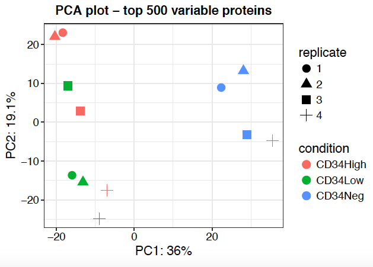

PCA_plot

1. **Heatmap**: The heatmap representation gives an overview of all significant/differentially expressed proteins (rows) in all samples (columns). This visualization allows the identfication of general trends such as if one sample or replicate is highly different compared to the others and might be considerd as an outlier. Additionally, the hierarchical clustering of samples (columns) indicates how related the different samples are and hierarchicalclustering of proteins (rows) identifies similarly behaving proteins. This analysis divides differncially expressed proteins into *six* clusters/groups. User also have option to download protein information from individual cluster.

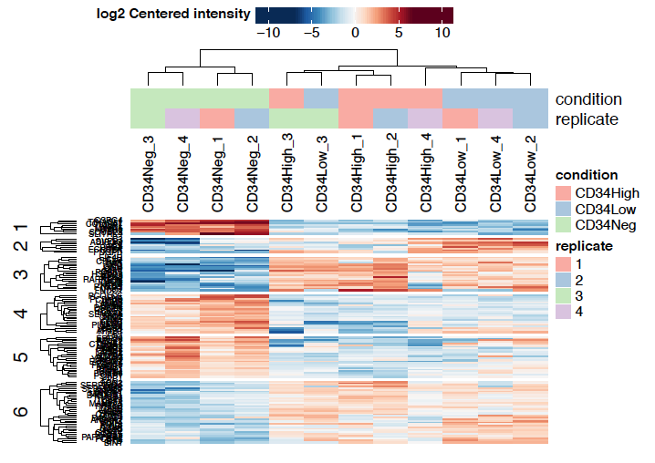

heatmap

1. **Volcano plot**: A volcano plot is generated for each pairwise comparison. It is a graphical visualization by plotting the “Fold Change (Log2)” on the x-axis versus the –log10 of the “ *p-value*” on the y-axis. Interesting candidate proteins are located in the left and right upper quadrant. User can toggle the display name checkbox to highlight names of differencially expressed proteins or use ‘adjusted *p-value*’ as y-axis. Importantly, user can highlight protein or their interest (colored moroon) by selecting the row from “**LFQ Results Table**”. This highlighted plot can be downloaded using " *Save Highlited Plot*" button.

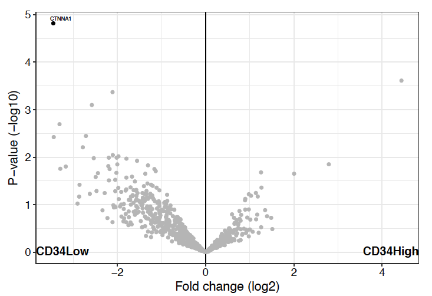

volcano_plot

#### QC plots

1. **Sample Correlation Plot**: A correlation matrix is plotted as a heatmap to visualize the Pearson correlation coefficients between the different samples.

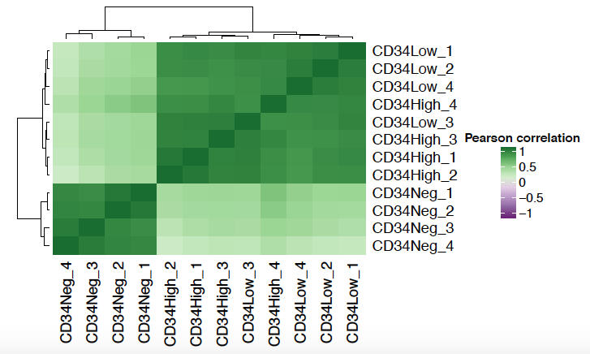

2. **Sample CVs Plots**: A plot representing distribution of protein level coefficient of variation for each condition. Each plot also contains a vertical line representing median CVs percentage withing that condition.

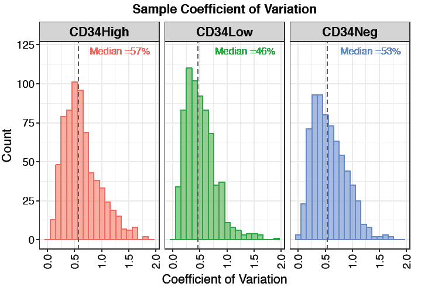

3. **Protein Numbers**: A bar-plot representing number of proteins identified and quantified in each sample.

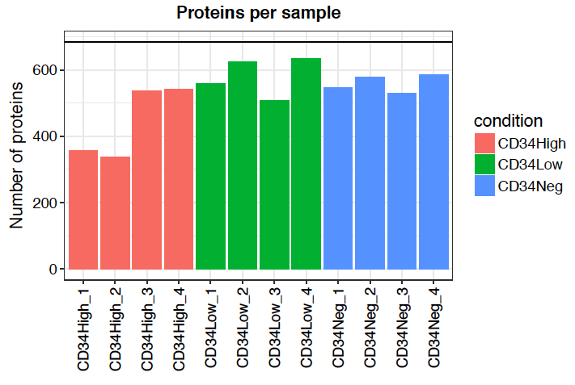

4. **Sample coverage**: A plot highlighting overlap between identified proteins across all samples in the experiment.

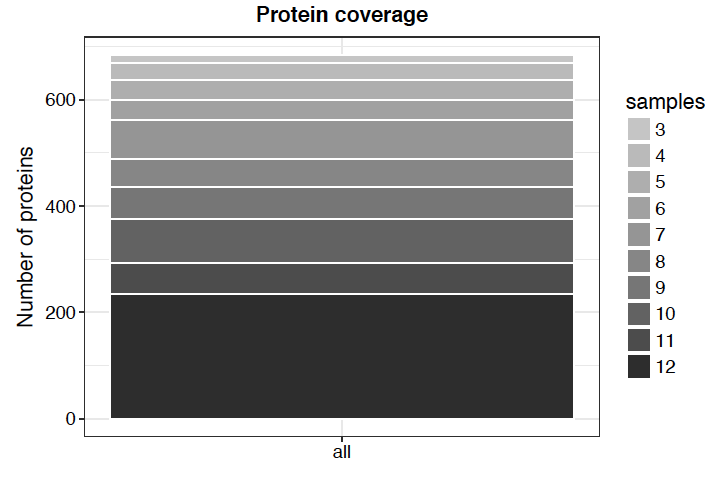

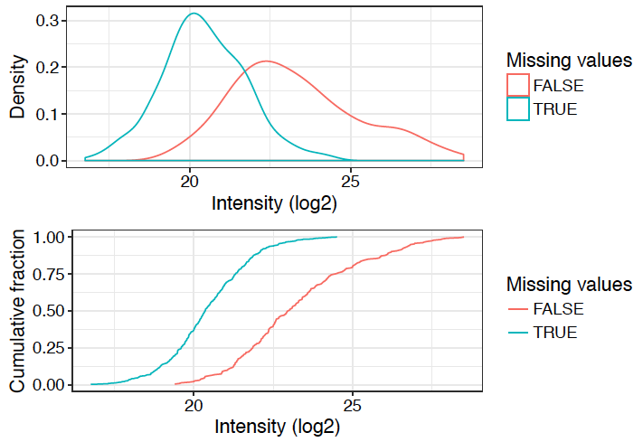

7. **Missing values- Heatmap**: To explore the pattern of missing values in the data, a heatmap is plotted indicating whether values are missing (0) or not (1). Only proteins with at least one missing value are visualized.

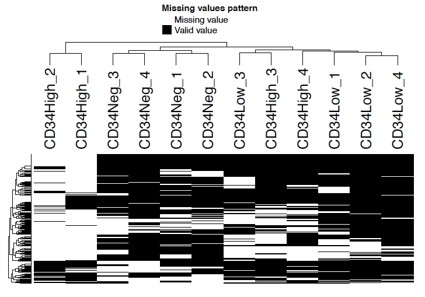

8. **Imputation**: A desity plot of protein intensity (log2) distrubution for each condition after and before missing value imputation being performed.

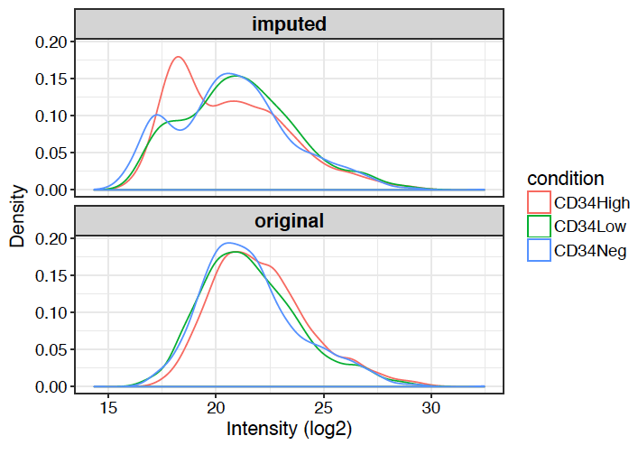

9. *p-value* Histogram: A histogram of p-value distribution for all the proteins across all pairwise comparison.

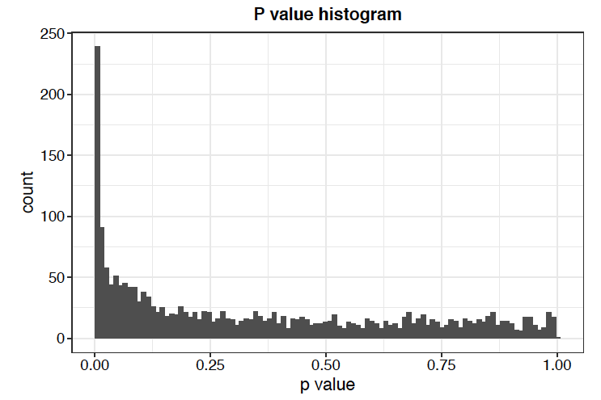

#### Download options

- **Download tables** (csv format)
1. Results: Same as *LFQ Results Table*
2. Unimputed data matrix: Original protein intensities before imputation in each sample.
3. Imputed data matrix: Protein intensities after performing selected imputaion method
4. Full results: Combined table of all above data outputs i.e. with and without imputation information along with fold change and p-values.
- **Download Report** (word format) A summary report document including some statistics and plots.
- **Download Plots** (PDF format) A PDF document containing all the plots generated during the analysis.